# R Notebook

### Submitted by - Swenal Fargose

### Course Name - Intro Data Mining/ Machine Learning(DA 5030)

### Topic - Signature Project - Labor Condition Application(LCA) Status Prediction

```
                    Problem statement/ Business Understanding:
```

Talent Acquisition has now become very difficult part in every company, be it a big organization or a new start up. Hiring skilled and right person is very important. Similarly, retaining the employee is also one of the major things that is evaluated before hiring him/ her.  
In corporate America many tech jobs have applications coming from international candidates. These candidates need sponsorship to work within the US locations. Every employer willing to hire an international employee (with or without STEM US degree) will need to sponsor for the employee and help them obtain work authorization visa(H1B) visa. With a vast number of employees applying each year, the Department of Labor (DOL) must certify a Labor Condition Application(LCA) as a prerequisite for H1B lottery.  
Department of Labor does not certify an LCA for all the employers or the job titles. And thus, every employer needs to know which job titles or locations have highest acceptance rate. So that they can hire only international candidates for those specified roles and locations or seeing other parameters.  
Thus, to help the employers decide on this and for the employees who are applying, a Data mining and Machine Learning techniques are used to build and deploy a model to predict the LCA approval.

```
                             Data acquisition and source -
```

```
                                  Data quality-
```

The quality of the data can be trusted as the data comes from the DOL. The data used is taken from Kaggle.com directly, however the metrics and attributes were validated from the original source.

```
                               Lets's begin by reading the datafile
```

```r
#Setting up a working directory
setwd("C:\\Users\\Swenal\\Desktop\\DM_ML Spring 2018")
#Reading data into a dataframe
Data <-read.csv("H-1B_Disclosure_Data_FY17.csv", sep=",",header = TRUE, na.strings=c("","NA"))
str(Data) #Structure of the data - output
```

```
'data.frame':   624650 obs. of  53 variables:
 $ X                          : int  0 1 2 3 4 5 6 7 8 9 ...
 $ CASE_NUMBER                : Factor w/ 624650 levels "I-200-09183-783797",..: 17943 19314 19200 34125 7179 8490 18196 18183 18358 18390 ...
 $ CASE_STATUS                : Factor w/ 4 levels "CERTIFIED","CERTIFIED-WITHDRAWN",..: 2 2 2 4 2 2 2 2 2 2 ...
 $ CASE_SUBMITTED             : Factor w/ 1323 levels "2011-03-23","2011-03-28",..: 770 779 785 961 458 476 771 771 773 774 ...
 $ DECISION_DATE              : Factor w/ 358 levels "2016-10-01","2016-10-02",..: 1 1 1 1 2 2 2 2 2 2 ...
 $ VISA_CLASS                 : Factor w/ 4 levels "E-3 Australian",..: 2 2 2 2 2 2 2 2 2 2 ...
 $ EMPLOYMENT_START_DATE      : Factor w/ 1598 levels "2011-09-22","2011-09-23",..: 1000 1006 1030 1169 474 666 1015 1016 1016 1019 ...
 $ EMPLOYMENT_END_DATE        : Factor w/ 1645 levels "2010-09-17","2014-09-11",..: 1046 1052 1076 1214 519 713 1060 1061 1061 1062 ...
 $ EMPLOYER_NAME              : Factor w/ 71170 levels ".CLUB DOMAINS, LLC",..: 18169 17810 19465 30800 7632 59874 13075 13075 13075 13075 ...
 $ EMPLOYER_BUSINESS_DBA      : Factor w/ 9441 levels "--","---","& SURVEYORS, D.P.C.",..: NA NA NA NA NA NA 1757 1757 1757 1757 ...
 $ EMPLOYER_ADDRESS           : Factor w/ 64378 levels "# 200 MIDDLESEX ESSEX TURNPIKE",..: 27745 27745 7995 17086 24962 32466 34640 34640 34640 34640 ...
 $ EMPLOYER_CITY              : Factor w/ 5123 levels ", KENOSHA",", ROCKVILLE CENTER",..: 3807 3807 4794 2512 5000 187 2120 2120 2120 2120 ...
 $ EMPLOYER_STATE             : Factor w/ 57 levels "AK","AL","AR",..: 18 18 9 26 32 13 36 36 36 36 ...
 $ EMPLOYER_POSTAL_CODE       : Factor w/ 10962 levels "00641","00646",..: 6533 6533 2581 5623 3290 3701 1195 1195 1195 1195 ...
```

[output cut: 39 more lines]

```
                             Data attributes and description-
```

There are many features associated with this data. However, the key predictors that are considered for Analysis are:

. Class variable (Response Variable) - CASE_STATUS: Status associated with the decision - (Certified, Denied, Certified-withdrawn, withdrawn)  
. CASE_SUBMITTED: Date when the application was submitted to the Department of Labor  
. VISA_CLASS: These include primarily H1b and other h1B classes like H1B1 Chile, H1B1 Singapore.  
. EMPLOYMENT_START_DATE, EMPLOYMENT_END_DATE: Starting and Ending date of employment  
. EMPLOYER_NAME: Name of the employer requesting  
. EMPLOYER_ADDRESS, EMPLOYER_CITY, EMPLOYER_STATE, EMPLOYER_POSTAL_CODE, EMPLOYER_COUNTRY, EMPLOYER_PROVINCE, EMPLOYER_PHONE, EMPLOYER_PHONE_EXT: Employer related information  
. AGENT_ATTORNEY_NAME, AGENT_ATTORNEY_CITY, AGENT_ATTORNEY_STATE: Agent related information  
. JOB_TITLE: Title of the job  
. SOC_CODE, SOC_NAME: Details associated with Standard Occupational Classification (SOC) system  
. NAIC_CODE: Industry code classified by North American Industrial Classification System  
. TOTAL_WORKERS: Number of foreign workers requested by that employer  
. FULL_TIME_POSITION: Y stands for full-time and N stands for Part time.  
. PREVAILING_WAGE: Wage for job being requested.  
. PW_UNIT_OF_PAY, PW_SOURCE_YEAR, PW_SOURCE_OTHER: Details related to prevailing wage(PW)  
. WAGE_RATE_OF_PAY_FROM, WAGE_RATE_OF_PAY_TO, WAGE_UNIT_OF_PAY: pay dates  
. H-1B_DEPENDENT: Y stands for yes and N otherwise  
. WILLFUL_VIOLATOR: Y stands for yes and N otherwise  
. WORKSITE_CITY, WORKSITE_COUNTY, WORKSITE_STATE,  
. WORKSITE_POSTAL_CODE: Worksite details  
. ORIGINAL_CERT_DATE: Original date of decision

```
                               Feature Selection:
```

Feature selection is an art. A great data science professional will consider features based on the values present in the predictor. For instance, redundant columns, missing value columns will not provide us any valuable information and hence can be eliminated.  
There are 52 different predictors in the dataset. Should one use these? Certainty not! More predictors certainly do not mean our model will work best. In most cases in fact it is best to select only a few, but most significant variables in training the model. This is because, having only the required and most significant attributes will give better accuracy results and a model overall than adding all the predictors. Also, this can slow down the run time performance of the model. Also, it is very possible that with more predictors the model will tend to overfit to that dataset.  
There are many ways which help us determine which features are most important in our model. Some of the examples include Forward Elimination, backward Elimination, PCA. Similarly, there are various other methods which gives us our ideal variables/ features.

```r
#Selecting only columns we need.Others are either redundant or have no significance.
#Though the correlation between the variables is not possible the domain knowledge is used here to select the right and accurate predictors for building a classifier. The variables not considered are address(state is included), zipcodes, job_titles(SOC_names which is equivalent is considered), Irrelavanet employer, employee and/ or agent specific variables.
Data1 <- subset(Data, select=c("CASE_STATUS",
"DECISION_DATE",
"EMPLOYMENT_START_DATE",
"EMPLOYMENT_END_DATE",
"VISA_CLASS",
"PW_UNIT_OF_PAY",
"TOTAL_WORKERS",
"SOC_NAME",
"AGENT_REPRESENTING_EMPLOYER",
"PREVAILING_WAGE",
"CASE_SUBMITTED",
"FULL_TIME_POSITION",
"WILLFUL_VIOLATOR",
"H1B_DEPENDENT",
"PW_SOURCE",
"WORKSITE_STATE")) #Using subset function to select only the records we need and storing it in a new data frame
summary(Data1) #output - summary of the data. We can see that the reponse variable has 4 levels.
```

```
              CASE_STATUS        DECISION_DATE    EMPLOYMENT_START_DATE
 CERTIFIED          :545694   2017-03-23: 17362   2017-09-01: 28425
 CERTIFIED-WITHDRAWN: 49704   2017-03-16: 15468   2017-08-01: 12984
 DENIED             :  8480   2017-03-21: 11921   2017-09-15: 11067
 WITHDRAWN          : 20772   2017-03-22: 11200   2017-10-01: 10215
                              2017-03-27: 10720   2017-07-01:  9110
                              2017-03-15: 10517   (Other)   :552820
                              (Other)   :547462   NA's      :    29
 EMPLOYMENT_END_DATE           VISA_CLASS       PW_UNIT_OF_PAY   TOTAL_WORKERS
 2020-08-31: 17753   E-3 Australian : 12157   Bi-Weekly:    57   Min.   :  0.000
 2020-09-01: 13063   H-1B           :610304   Hour     : 38779   1st Qu.:  1.000
 2020-07-31:  9137   H-1B1 Chile    :   935   Month    :   327   Median :  1.000
 2020-09-14:  9038   H-1B1 Singapore:  1254   Week     :   140   Mean   :  1.894
 2020-09-15:  8333                            Year     :585301   3rd Qu.:  1.000
 (Other)   :567296                            NA's     :    46   Max.   :155.000
 NA's      :    30
                                  SOC_NAME      AGENT_REPRESENTING_EMPLOYER
 SOFTWARE DEVELOPERS, APPLICATIONS    :124507   N   :176798
 COMPUTER SYSTEMS ANALYSTS            : 93611   Y   :351346
 COMPUTER PROGRAMMERS                 : 66603   NA's: 96506
 COMPUTER OCCUPATIONS, ALL OTHER      : 53440
 SOFTWARE DEVELOPERS, SYSTEMS SOFTWARE: 18401
 (Other)                              :268085
 NA's                                 :     3
 PREVAILING_WAGE        CASE_SUBMITTED   FULL_TIME_POSITION WILLFUL_VIOLATOR
 Min.   :        0   2017-03-15: 12287   N   : 13876        N   :610428
 1st Qu.:    56826   2017-03-17: 12242   Y   :610769        Y   :   477
 Median :    70221   2017-03-10: 11839   NA's:     5        NA's: 13745
 Mean   :    73211   2017-03-16: 11799
 3rd Qu.:    89149   2017-03-21: 11254
 Max.   :201622735   2017-03-09: 11029
 NA's   :1           (Other)   :554200
 H1B_DEPENDENT PW_SOURCE      WORKSITE_STATE
 N   :377051   CBA  :  4053   CA     :119409
 Y   :233857   DBA  :    22   TX     : 66163
 NA's: 13742   OES  :504806   NY     : 54974
               Other:115702   NJ     : 42571
               SCA  :    21   IL     : 32082
               NA's :    46   (Other):309442
                              NA's   :     9
```

```
                      Data Cleaning and Preparation:
```

Data Cleaning and preparation is one of the most important steps of CRISP-DM. It includes making your data ready to train your mode. Data can be having missing values. Irrelevant attributes considering your problem statement, redundant attributes. Thus, data needs to be cleaned so that you model can accept that data for training it. Sometimes data needs to be scaled is there is a skewness. Also, many a times in binary classification the two levels are not equally distributed and hence sampling of the data needs to be done for best results.

1. The response variable has four levels, of which certified-withdrawn and Withdrawn are employee actions and not related to a decision made by DOL. Hence removing those two levels.

2)Multiplying the unit of pay and the prevailing pay to make the prevailing wage annually throughout.

3. Are your predictor values categorical or numerical? Many models like regression model will need the data to be numerical. In such cases, dummy coding needs to be done to change the categorical values to dummy codes.

```
                                     DATA PLOTS
```

Case_Status

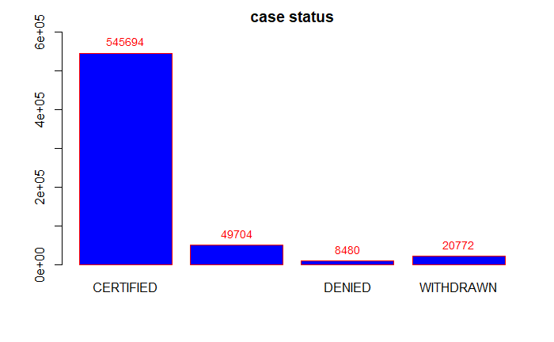

```r
case_status <- table(Data1$CASE_STATUS) #Creating a dataobject
ylim= c(0,1.1*max(case_status)) #Using Ylimit to 1.1 times the max value as plot was not clear
#creating barplot using barplot function
bp<-barplot(case_status, main='case status', border="red",col="blue", ylim= ylim)
#Giving count labels to the bars
text(bp, y=case_status,label=case_status, pos=3, cex=0.9, col="red")
```

Willful_Violator

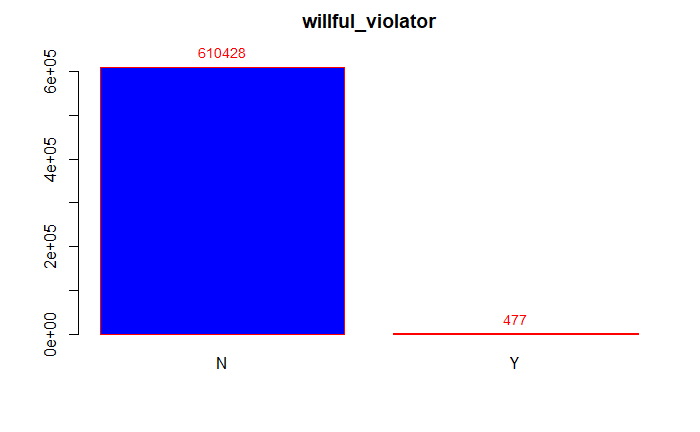

```r
willfull_violater <- table(Data1$WILLFUL_VIOLATOR)
ylim= c(0,1.1*max(willfull_violater))
bp<-barplot(willfull_violater, main='willful_violator', border="red",col="blue", ylim= ylim)
text(bp, y=willfull_violater,label=willfull_violater, pos=3, cex=0.9, col="red")
```

Full_time_position

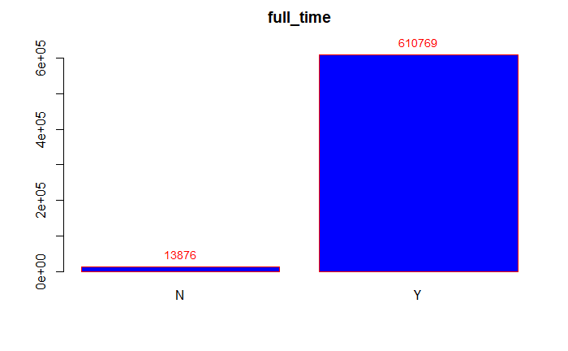

```r
full_time <- table(Data1$FULL_TIME_POSITION)
ylim= c(0,1.1*max(full_time))
bp<-barplot(full_time, main='full_time', border="red",col="blue", ylim= ylim)
text(bp, y=full_time,label=full_time, pos=3, cex=0.9, col="red")
```

Visa_class

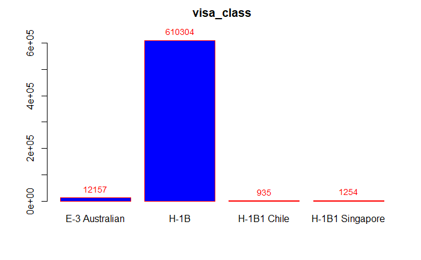

```r
visa_class <- table(Data1$VISA_CLASS)
ylim= c(0,1.1*max(visa_class))
bp<-barplot(visa_class, main='visa_class', border="red",col="blue", ylim= ylim)
text(bp, y=visa_class,label=visa_class, pos=3, cex=0.9, col="red")
```

# Subsetting the desired levels

```r
#Extracting only two levels from the response variable. The other two levels are candidate action taken after the LCA decision
Data2 <- subset(Data1, Data1$CASE_STATUS =='CERTIFIED') #subsetting the certified types
Data3 <- subset(Data1, Data1$CASE_STATUS =='DENIED')    #subsetting the denied types
Data4 <- rbind(Data2, Data3) #Binding the two types
summary(Data4) #Lets see the output here - the other two levels are gone for CASE_STATUS
```

```
              CASE_STATUS        DECISION_DATE    EMPLOYMENT_START_DATE
 CERTIFIED          :545694   2017-03-23: 16950   2017-09-01: 26279
 CERTIFIED-WITHDRAWN:     0   2017-03-16: 14980   2017-08-01: 12171
 DENIED             :  8480   2017-03-21: 11348   2017-09-15: 10302
 WITHDRAWN          :     0   2017-03-22: 10713   2017-10-01:  9626
                              2017-03-27: 10439   2017-07-01:  8454
                              2017-03-24: 10101   (Other)   :487316
                              (Other)   :479643   NA's      :    26
 EMPLOYMENT_END_DATE           VISA_CLASS       PW_UNIT_OF_PAY   TOTAL_WORKERS
 2020-08-31: 16375   E-3 Australian : 11068   Bi-Weekly:    53   Min.   :  1.000
 2020-09-01: 12283   H-1B           :541102   Hour     : 34691   1st Qu.:  1.000
 2020-07-31:  8607   H-1B1 Chile    :   861   Month    :   296   Median :  1.000
 2020-09-14:  8371   H-1B1 Singapore:  1143   Week     :   125   Mean   :  1.966
 2020-09-15:  7775                            Year     :518967   3rd Qu.:  1.000
 (Other)   :500736                            NA's     :    42   Max.   :155.000
 NA's      :    27
                                  SOC_NAME      AGENT_REPRESENTING_EMPLOYER
 SOFTWARE DEVELOPERS, APPLICATIONS    :109269   N   :151182
 COMPUTER SYSTEMS ANALYSTS            : 83927   Y   :317010
 COMPUTER PROGRAMMERS                 : 58329   NA's: 85982
 COMPUTER OCCUPATIONS, ALL OTHER      : 47964
 COMPUTER SYSTEMS ANALYST             : 16697
 SOFTWARE DEVELOPERS, SYSTEMS SOFTWARE: 16481
 (Other)                              :221507
 PREVAILING_WAGE        CASE_SUBMITTED   FULL_TIME_POSITION WILLFUL_VIOLATOR
 Min.   :        0   2017-03-15: 11359   N   : 12619        N   :541311
 1st Qu.:    57346   2017-03-17: 11339   Y   :541553        Y   :   340
 Median :    70616   2017-03-16: 10895   NA's:     2        NA's: 12523
 Mean   :    73579   2017-03-10: 10854
 3rd Qu.:    89669   2017-03-21: 10420
 Max.   :201622735   2017-03-20: 10054
 NA's   :1           (Other)   :489253
 H1B_DEPENDENT PW_SOURCE      WORKSITE_STATE
 N   :331358   CBA  :  3471   CA     :104859
 Y   :210296   DBA  :    22   TX     : 58574
 NA's: 12520   OES  :450262   NY     : 49237
               Other:100356   NJ     : 37504
               SCA  :    20   IL     : 28855
               NA's :    43   (Other):275138
                              NA's   :     7
```

Passing the date directly to the model can be misleading and it will be difficult for models to comphrend the data. Thus splitting the DATE into YEARS, MONTHS and DAYS as individual componenets.

```r
#extracting the year, months and days from the DATES
#Here Splitting Date into Year, Month and Days for fitting the models
Data4$CASE_SUBMITTED_YEAR <- as.numeric(format(as.Date(Data4$CASE_SUBMITTED, format="%Y-%m-%d"),"%Y")) #using as.DATE function to convert the value into Date format and then extracting the individual component
Data4$CASE_SUBMITTED_MONTH <- as.numeric(format(as.Date(Data4$CASE_SUBMITTED, format="%Y-%m-%d"),"%m"))
Data4$CASE_SUBMITTED_DAY <- as.numeric(format(as.Date(Data4$CASE_SUBMITTED, format="%Y-%m-%d"),"%d"))
#Similarly doing the transformations for the Decision_date
Data4$DECISION_DATE_YEAR <- as.numeric(format(as.Date(Data4$DECISION_DATE, format="%Y-%m-%d"),"%Y"))
Data4$DECISION_DATE_MONTH <- as.numeric(format(as.Date(Data4$DECISION_DATE, format="%Y-%m-%d"),"%m"))
Data4$DECISION_DATE_DAY <- as.numeric(format(as.Date(Data4$DECISION_DATE, format="%Y-%m-%d"),"%d"))
#Similarly doing the transformations for the EMPLOYMENT_START_DATE
Data4$EMPLOYMENT_START_DATE_YEAR<- as.numeric(format(as.Date(Data4$EMPLOYMENT_START_DATE, format="%Y-%m-%d"),"%Y"))
Data4$EMPLOYMENT_START_DATE_MONTH<- as.numeric(format(as.Date(Data4$EMPLOYMENT_START_DATE, format="%Y-%m-%d"),"%m"))
Data4$EMPLOYMENT_START_DATE_DAY <- as.numeric(format(as.Date(Data4$EMPLOYMENT_START_DATE, format="%Y-%m-%d"),"%d"))
#Similarly doing the transformations for the EMPLOYMENT_END_DATE
Data4$EMPLOYMENT_END_DATE_YEAR <- as.numeric(format(as.Date(Data4$EMPLOYMENT_END_DATE, format="%Y-%m-%d"),"%Y"))
Data4$EMPLOYMENT_END_DATE_MONTH <- as.numeric(format(as.Date(Data4$EMPLOYMENT_END_DATE, format="%Y-%m-%d"),"%m"))
Data4$EMPLOYMENT_END_DATE_DAY<- as.numeric(format(as.Date(Data4$EMPLOYMENT_END_DATE, format="%Y-%m-%d"),"%d"))
#Deleting the original date columns from the dataframe and retaining the individual dat components. Using subset function again here.
Data4 <- subset( Data4, select = -CASE_SUBMITTED)
Data4 <- subset( Data4, select = -DECISION_DATE)
Data4 <- subset( Data4, select = -EMPLOYMENT_START_DATE)
Data4 <- subset( Data4, select = -EMPLOYMENT_END_DATE)
#Lets see how the data looks now
str(Data4)  #Output
```

```
'data.frame':   554174 obs. of  24 variables:
 $ CASE_STATUS                : Factor w/ 4 levels "CERTIFIED","CERTIFIED-WITHDRAWN",..: 1 1 1 1 1 1 1 1 1 1 ...
 $ VISA_CLASS                 : Factor w/ 4 levels "E-3 Australian",..: 2 2 2 2 2 2 2 2 2 2 ...
 $ PW_UNIT_OF_PAY             : Factor w/ 5 levels "Bi-Weekly","Hour",..: 5 5 5 5 5 5 5 5 2 5 ...
 $ TOTAL_WORKERS              : int  1 1 1 1 1 1 1 1 1 4 ...
 $ SOC_NAME                   : Factor w/ 867 levels "13-2011","15-1121",..: 766 863 766 766 792 210 37 766 476 766 ...
 $ AGENT_REPRESENTING_EMPLOYER: Factor w/ 2 levels "N","Y": 2 2 2 2 1 2 2 2 2 2 ...
 $ PREVAILING_WAGE            : num  102149 56784 85197 117770 66414 ...
 $ FULL_TIME_POSITION         : Factor w/ 2 levels "N","Y": 2 2 2 2 2 2 2 2 2 2 ...
 $ WILLFUL_VIOLATOR           : Factor w/ 2 levels "N","Y": 1 1 1 1 1 1 1 1 1 1 ...
 $ H1B_DEPENDENT              : Factor w/ 2 levels "N","Y": 2 2 1 1 1 2 1 2 1 1 ...
 $ PW_SOURCE                  : Factor w/ 5 levels "CBA","DBA","OES",..: 3 3 3 3 3 3 3 3 3 4 ...
 $ WORKSITE_STATE             : Factor w/ 57 levels "AK","AL","AR",..: 5 39 49 5 5 5 38 49 5 20 ...
 $ CASE_SUBMITTED_YEAR        : num  2016 2016 2016 2016 2016 ...
 $ CASE_SUBMITTED_MONTH       : num  9 9 9 9 9 9 9 9 9 9 ...
 $ CASE_SUBMITTED_DAY         : num  27 27 27 27 27 27 27 27 27 27 ...
 $ DECISION_DATE_YEAR         : num  2016 2016 2016 2016 2016 ...
 $ DECISION_DATE_MONTH        : num  10 10 10 10 10 10 10 10 10 10 ...
 $ DECISION_DATE_DAY          : num  3 3 3 3 3 3 3 3 3 3 ...
 $ EMPLOYMENT_START_DATE_YEAR : num  2016 2016 2017 2017 2016 ...
 $ EMPLOYMENT_START_DATE_MONTH: num  10 9 3 3 11 10 10 10 9 9 ...
 $ EMPLOYMENT_START_DATE_DAY  : num  1 27 27 15 7 3 17 4 30 27 ...
 $ EMPLOYMENT_END_DATE_YEAR   : num  2019 2019 2020 2020 2017 ...
 $ EMPLOYMENT_END_DATE_MONTH  : num  9 9 3 3 8 10 10 10 9 9 ...
 $ EMPLOYMENT_END_DATE_DAY    : num  20 21 26 12 31 2 16 3 29 26 ...
```

Many models unfortunately will not accept non numeric predictors and hence we will need to convert the categorical variables into dummies to fit the model. The categorical variables will be converted into n-1 dummy variables– where n stands for number levels in the categorical variable.

For instance the SOC_Name has many levels(treating each unique name as a category) and thus we will have a large set of dummy variables. This is infeasible, to do that, I have created smaller clusters/ groups of the occupactions based on the similar categories and grouped them into one. For example all the types of engineers(Computer, mechanical, electrical, IT, Chemical, etc will be groupped into one type as ’ENGINEER)

```r
#Here creating a new coulm SOC.NAME(occupation) and creating groups by grepping keywords.
Data4$SOC.NAME<-NA  #Creating a new column
#Finding keywords and with ignoring cases using the grep() function and assigning a new category to the group in the new column
Data4$SOC.NAME[grep("software", Data4$SOC_NAME, ignore.case = T)]<-"SOFTWARE-ANALYSTS"
Data4$SOC.NAME[grep("engineer",Data4$SOC_NAME, ignore.case = T)]<-"ENGINEERS"
Data4$SOC.NAME[grep("computer",Data4$SOC_NAME, ignore.case = T)]<-"COMPUTER-ANALYSTS"
Data4$SOC.NAME[grep("technician",Data4$SOC_NAME, ignore.case = T)]<-"TECHNICIANS/CONSULTANTS"
Data4$SOC.NAME[grep("executive",Data4$SOC_NAME, ignore.case = T)]<-"EXECUTIVES"
Data4$SOC.NAME[grep("teacher",Data4$SOC_NAME, ignore.case = T)]<-"EDUCATORS/TUTORS"
Data4$SOC.NAME[grep("accountant",Data4$SOC_NAME, ignore.case = T)]<-"ACCOUNTANTS"
Data4 <- subset( Data4, select = -SOC_NAME) #Removing the original column
```

Lets see if there is any correlation between the Prevaling wage and unit of pay

```r
Data5 <- Data4  #Retaining Data4 and storing it into Data5
#Considering only complete cases using complete.cases() function to do our furthur preproecssing
Data6<-Data5[complete.cases(Data5),]
cor(Data6$PREVAILING_WAGE, as.numeric(as.factor(Data6$PW_UNIT_OF_PAY))) #correlation between prevailing wage and unit_of_pay
```

```
[1] 0.04540904
```

Though we do not see a good corelation here– this is because its always hard to find correlation between categorical value and numerical values. Also due to the presence of the outliers the correlation may be weak.

Thus, the next stage in preprocesssin will include making the PREVAILING_WAGE column uniform(WAGE ANNUALLY). There are different types of rates given in the original dataset. The two columns that I have used here are PW_UNIT_OF_PAY and WAGE. The wage type is transformed annually.

```r
#creating uniform annual wages type using for loop. If the PW_PAY_UNIT is Hour muiltply the wage column by 2080(working hours in a year). If its month, multiply by 12(months in a year). if Its week, multiply by 52( working weeks in a year). If its bi-weekly multiply by 26(26 fortnights in a year) and lastly, if its already in a year, leave the wage column as it is.
for(i in 1:nrow(Data6))
{
  if(Data6$PW_UNIT_OF_PAY[i]=="Hour")
  {
    Data6$PREVAILING_WAGE[i]<-Data6$PREVAILING_WAGE[i]*2080
  }
  else if(Data6$PW_UNIT_OF_PAY[i]=="Month")
  {
    Data6$PREVAILING_WAGE[i]<-Data6$PREVAILING_WAGE[i]*12
  }
  else if(Data6$PW_UNIT_OF_PAY[i]=="Week")
  {
    Data6$PREVAILING_WAGE[i]<-Data6$PREVAILING_WAGE[i]*52
  }
  else if(Data6$PW_UNIT_OF_PAY[i]=="Bi-Weekly")
  {
    Data6$PREVAILING_WAGE[i]<-Data6$PREVAILING_WAGE[i]*26
  }
}
Data6 <- subset( Data6, select = -PW_UNIT_OF_PAY) #dropping PW_UNIT_OF_PAY
#str(Data6) #output
```

```
                                   outliers
```

Outliers are data points that are few standard deviations away from the mean. There can be many reasons why outliers can be introduced in the data. Some of the common reasons are misleading data, error in data recording or in some cases they are correct data but just are simply odd man out. Such data points need to be removed from our datset in order to have a normalized data curve and also as it can lead to any incorrect fitting of our model and this lead to poor accuracy.

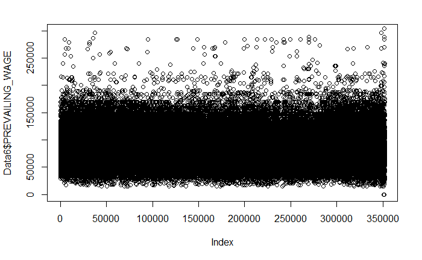

```r
library(ggplot2) #loading library
plot(Data6$PREVAILING_WAGE, ylim =c(0,300000))  #plotting graph of the prevailing wage I just calculated in the code above. We can see there are outliers in the data. POints avoce 250000 are ouliers
```

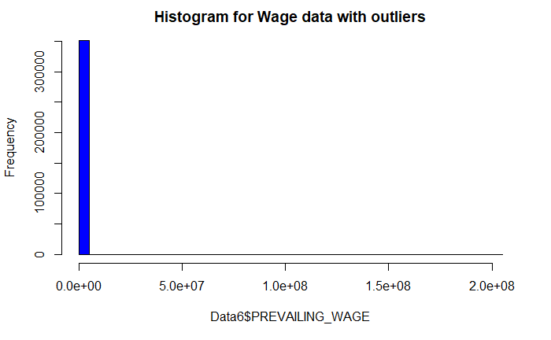

```r
hist(Data6$PREVAILING_WAGE, breaks=30, col="blue", main="Histogram for Wage data with outliers") #output
```

There can be several ways to treat outliers. Using Z-score method, IQR, boxplots, etc. I have used plots here. which gives me the correct estimate of the outliers. I also tried to find outliers by using the Z-score method, however due to the variance and vast amount of data this method was not successful in finding the right outliers.

```r
# s<-sd(Data6$PREVAILING_WAGE);           # Calculating S.D and storing in s
# m<-mean(Data6$PREVAILING_WAGE);        # Calculating Mean and storing in m
# delta<-m-Data6$PREVAILING_WAGE;         # Calculating (mean-Value)
# z<-delta/s;                         # Calculating Z
# z<-abs(z);                          # Calculating absolute value of Z
# outliers <- which(z>1.5);           # Detecting Z values greater than 1.5
# Data6[outliers,"PREVAILING_WAGE"]
```

What do we do with the outliers? Remove them? We could but data imputataion is the right method. Using the Median of the data to impute the new values in our outliers.

Lets impute the median values to the outliers

```r
#subsetting the outliers
Data_wage_outliers <- subset(Data6, PREVAILING_WAGE>250000 | PREVAILING_WAGE<20000)
#Subsetting the clean data
Data_wage_no_outliers <- subset(Data6, PREVAILING_WAGE<250000 & PREVAILING_WAGE>20000)
#finding median and replacing it with outlier data
Data_wage_outliers$PREVAILING_WAGE <- median(Data_wage_no_outliers$PREVAILING_WAGE)
Data6 <- rbind(Data_wage_outliers, Data_wage_no_outliers) #Binding clean data and imputed outliers
```

Let’s see how our new data without outliers look

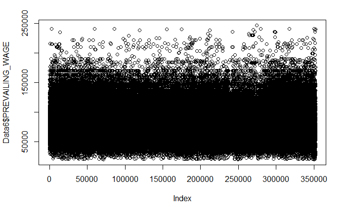

```r
library(ggplot2)
plot(Data6$PREVAILING_WAGE)  #lets see the plot now.
```

```
NAs produced by integer overflow
```

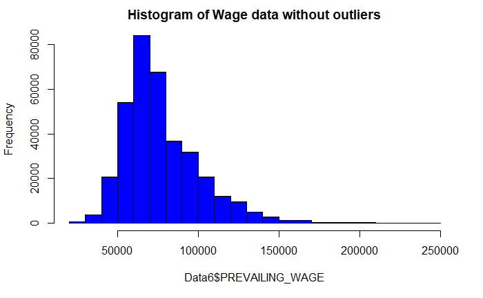

```r
hist(Data6$PREVAILING_WAGE, breaks=30, col="blue", main="Histogram of Wage data without outliers") #histogram output
```

Removing states with lower counts – this is primarily done to fit Random forest. Random forest can not handle more than 53 categories in a predictor.

```r
#Using dplyr function to use show groupby plots
library("dplyr")  #Loading library
#Showing states with lowest 5 counts
grp3 <- group_by(Data6, WORKSITE_STATE)
last5_state_count <- summarise(grp3, last5_state_count = n())
top_n(last5_state_count, -5, wt=last5_state_count)
```

| WORKSITE_STATE | last5_state_count |
| --- | --- |
| AK | 67 |
| FM | 1 |
| PW | 1 |
| VI | 16 |
| WY | 55 |

```r
# #subsetting data without taking these states -- AK, MT, SD, VI, WY, PW, FM
Data6 <- Data6 [(!(Data6$WORKSITE_STATE=="AK") & !(Data6$WORKSITE_STATE=="MT") & !(Data6$WORKSITE_STATE=="SD") & !(Data6$WORKSITE_STATE=="VI") & !(Data6$WORKSITE_STATE=="WY") & !(Data6$WORKSITE_STATE=="PW") & !(Data6$WORKSITE_STATE=="FM")),]
Data6$WORKSITE_STATE <- factor(Data6$WORKSITE_STATE) #converting Worksite to factor to drop empty levels in the dataset
Data6$CASE_STATUS <- factor(Data6$CASE_STATUS)  #Converting CASE_STATUS to factor
```

```
                                Sampling Data:
```

Data sampling can be done for removing imbalance in the Data for classification. No one wants to have number of cases in one class to be significantly more or less than the other class. This is because the model that will be built for prediction is more likely to be biased on inaccurate. There are various ways to handle this like: Under-sampling, Over-sampling, cluster based over-sampling, and various other Ensemble techniques.

```r
#ROSE package is used for purpose of sampling. ovun.sample function from the ROSE library is used for this purpose.
#install.packages("ROSE")
library("ROSE")  #Loading library
prop.table(table(Data6$CASE_STATUS))  #seeing the ratio before sampling
```

```
 CERTIFIED     DENIED
0.98890115 0.01109885
```

```r
#Data sampling for balanced class levels
Data_sampled <- ovun.sample(CASE_STATUS ~ ., data = Data6, method = "under", N = 15000, seed = 1)$data  #Using under sampling with N= 15000. This function will delete random cases from the dominant case level(certified) and make the dataset fairly balanced. I could use any number i wanted
#Data_sampled <- ovun.sample(CASE_STATUS ~ ., data = Data6, method = "both", p=0.5, N=50000, seed = 1)$data  #Tried using 'both' as method. This will delete additional cases from CERTIIED cases and replicate(add) more data in DENIED cases
prop.table(table(Data_sampled$CASE_STATUS)) #Seeing the ratio after sampling
```

```
CERTIFIED    DENIED
0.7398667 0.2601333
```

```r
Data_sampled.new <- Data_sampled  #passing the sampled data into new datafame
summary(Data_sampled.new)  #Now seeing the summary.
```

```
    CASE_STATUS              VISA_CLASS    TOTAL_WORKERS     AGENT_REPRESENTING_EMPLOYER
 CERTIFIED:11098   E-3 Australian :   20   Min.   :  1.000   N:5499
 DENIED   : 3902   H-1B           :14974   1st Qu.:  1.000   Y:9501
                   H-1B1 Chile    :    3   Median :  1.000
                   H-1B1 Singapore:    3   Mean   :  2.099
                                           3rd Qu.:  1.000
                                           Max.   :155.000

 PREVAILING_WAGE  FULL_TIME_POSITION WILLFUL_VIOLATOR H1B_DEPENDENT PW_SOURCE
 Min.   : 20230   N:  228            N:14986          N:8923        CBA  :   94
 1st Qu.: 61318   Y:14772            Y:   14          Y:6077        DBA  :    8
 Median : 71781                                                     OES  :11608
 Mean   : 76839                                                     Other: 3286
 3rd Qu.: 89502                                                     SCA  :    4
 Max.   :241134

 WORKSITE_STATE CASE_SUBMITTED_YEAR CASE_SUBMITTED_MONTH CASE_SUBMITTED_DAY
 CA     :2880   Min.   :2016        Min.   : 1.000       Min.   : 1.00
 TX     :1737   1st Qu.:2017        1st Qu.: 3.000       1st Qu.: 8.00
 NJ     :1042   Median :2017        Median : 3.000       Median :16.00
 NY     : 914   Mean   :2017        Mean   : 4.501       Mean   :15.46
 IL     : 785   3rd Qu.:2017        3rd Qu.: 5.000       3rd Qu.:22.00
 MA     : 586   Max.   :2017        Max.   :12.000       Max.   :31.00
 (Other):7056
 DECISION_DATE_YEAR DECISION_DATE_MONTH DECISION_DATE_DAY EMPLOYMENT_START_DATE_YEAR
 Min.   :2016       Min.   : 1.000      Min.   : 1.00     Min.   :2014
 1st Qu.:2017       1st Qu.: 3.000      1st Qu.: 9.00     1st Qu.:2017
 Median :2017       Median : 3.000      Median :17.00     Median :2017
 Mean   :2017       Mean   : 4.538      Mean   :16.65     Mean   :2017
 3rd Qu.:2017       3rd Qu.: 5.000      3rd Qu.:24.00     3rd Qu.:2017
 Max.   :2017       Max.   :12.000      Max.   :31.00     Max.   :2018

 EMPLOYMENT_START_DATE_MONTH EMPLOYMENT_START_DATE_DAY EMPLOYMENT_END_DATE_YEAR
 Min.   : 1.00               Min.   : 1.00             Min.   :2010
 1st Qu.: 5.00               1st Qu.: 4.00             1st Qu.:2020
 Median : 8.00               Median :13.00             Median :2020
 Mean   : 7.07               Mean   :13.16             Mean   :2020
 3rd Qu.: 9.00               3rd Qu.:21.00             3rd Qu.:2020
 Max.   :12.00               Max.   :31.00             Max.   :2021

 EMPLOYMENT_END_DATE_MONTH EMPLOYMENT_END_DATE_DAY   SOC.NAME
 Min.   : 1.000            Min.   : 1.00           Length:15000
 1st Qu.: 5.000            1st Qu.: 8.00           Class :character
 Median : 8.000            Median :16.00           Mode  :character
 Mean   : 7.094            Mean   :16.55
 3rd Qu.: 9.000            3rd Qu.:26.00
 Max.   :12.000            Max.   :31.00
```

```r
#Converting our response variable to binary variables
Data_sampled.new$CASE_STATUS <- ifelse(Data_sampled.new$CASE_STATUS=="CERTIFIED",1,0) #if its certified its 1 otherwise it is 0
Data_sampled.new$SOC.NAME <- as.factor(Data_sampled.new$SOC.NAME) #converting the SOC.NAME predictor to factor for creating dummy variables
Data_sampled.new$CASE_STATUS <- as.factor(Data_sampled.new$CASE_STATUS)  #converting the SOC.NAME predictor to factor for creating dummy variables
```

```
                                *Model Building:*
```

In this phase of CRISP-DM, the actual model will be built using the appropriate algorithm based on the data and type of machine learning one wants to achieve. Choosing the right type of ML algorithm is very important to get the best results out of your modeling.

```
                        BUILDING LOGISTIC REGRESSION MODEL
```

Logistic regression is a type of classification model for predicting a binary response variable. It is the first method that comes to everyone’s mind when it comes to classification of binary problems, i.e. class variable with two levels. Logistic regression predicts the probabilities of a class. Its values lie between 0 and 1.

```r
#install.packages("caret")
library("caret")  #Loading Caret package for using dummyVars function to create dummy variables.
dummy_variables_h1b<-dummyVars("~.",data=Data_sampled.new, fullRank = T) #Using dummyVars() function from the caret package to create dummy variables. Passing the (fullRank=T) parameter to the function which will give n-1 dummy variables
Data_h1b_final<-data.frame(predict(dummy_variables_h1b,newdata=Data_sampled.new)) #predicting this dummy object with the dataset and converting it into a dataframe.
summary(Data_h1b_final) #Seeing how the data looks with the dummy columns
```

```
 CASE_STATUS.1    VISA_CLASS.H.1B  VISA_CLASS.H.1B1.Chile VISA_CLASS.H.1B1.Singapore
 Min.   :0.0000   Min.   :0.0000   Min.   :0e+00          Min.   :0e+00
 1st Qu.:0.0000   1st Qu.:1.0000   1st Qu.:0e+00          1st Qu.:0e+00
 Median :1.0000   Median :1.0000   Median :0e+00          Median :0e+00
 Mean   :0.7399   Mean   :0.9983   Mean   :2e-04          Mean   :2e-04
 3rd Qu.:1.0000   3rd Qu.:1.0000   3rd Qu.:0e+00          3rd Qu.:0e+00
 Max.   :1.0000   Max.   :1.0000   Max.   :1e+00          Max.   :1e+00
 TOTAL_WORKERS     AGENT_REPRESENTING_EMPLOYER.Y PREVAILING_WAGE  FULL_TIME_POSITION.Y
 Min.   :  1.000   Min.   :0.0000                Min.   : 20230   Min.   :0.0000
 1st Qu.:  1.000   1st Qu.:0.0000                1st Qu.: 61318   1st Qu.:1.0000
 Median :  1.000   Median :1.0000                Median : 71781   Median :1.0000
 Mean   :  2.099   Mean   :0.6334                Mean   : 76839   Mean   :0.9848
 3rd Qu.:  1.000   3rd Qu.:1.0000                3rd Qu.: 89502   3rd Qu.:1.0000
 Max.   :155.000   Max.   :1.0000                Max.   :241134   Max.   :1.0000
 WILLFUL_VIOLATOR.Y  H1B_DEPENDENT.Y  PW_SOURCE.DBA       PW_SOURCE.OES
 Min.   :0.0000000   Min.   :0.0000   Min.   :0.0000000   Min.   :0.0000
 1st Qu.:0.0000000   1st Qu.:0.0000   1st Qu.:0.0000000   1st Qu.:1.0000
 Median :0.0000000   Median :0.0000   Median :0.0000000   Median :1.0000
 Mean   :0.0009333   Mean   :0.4051   Mean   :0.0005333   Mean   :0.7739
 3rd Qu.:0.0000000   3rd Qu.:1.0000   3rd Qu.:0.0000000   3rd Qu.:1.0000
 Max.   :1.0000000   Max.   :1.0000   Max.   :1.0000000   Max.   :1.0000
 PW_SOURCE.Other  PW_SOURCE.SCA       WORKSITE_STATE.AR WORKSITE_STATE.AZ
 Min.   :0.0000   Min.   :0.0000000   Min.   :0.000     Min.   :0.00000
 1st Qu.:0.0000   1st Qu.:0.0000000   1st Qu.:0.000     1st Qu.:0.00000
 Median :0.0000   Median :0.0000000   Median :0.000     Median :0.00000
 Mean   :0.2191   Mean   :0.0002667   Mean   :0.004     Mean   :0.01727
 3rd Qu.:0.0000   3rd Qu.:0.0000000   3rd Qu.:0.000     3rd Qu.:0.00000
 Max.   :1.0000   Max.   :1.0000000   Max.   :1.000     Max.   :1.00000
 WORKSITE_STATE.CA WORKSITE_STATE.CO WORKSITE_STATE.CT WORKSITE_STATE.DC
 Min.   :0.000     Min.   :0.00000   Min.   :0.00000   Min.   :0.000000
 1st Qu.:0.000     1st Qu.:0.00000   1st Qu.:0.00000   1st Qu.:0.000000
 Median :0.000     Median :0.00000   Median :0.00000   Median :0.000000
 Mean   :0.192     Mean   :0.01087   Mean   :0.01227   Mean   :0.004933
 3rd Qu.:0.000     3rd Qu.:0.00000   3rd Qu.:0.00000   3rd Qu.:0.000000
 Max.   :1.000     Max.   :1.00000   Max.   :1.00000   Max.   :1.000000
 WORKSITE_STATE.DE  WORKSITE_STATE.FL WORKSITE_STATE.GA WORKSITE_STATE.GU
 Min.   :0.000000   Min.   :0.00000   Min.   :0.00000   Min.   :0.0000000
 1st Qu.:0.000000   1st Qu.:0.00000   1st Qu.:0.00000   1st Qu.:0.0000000
 Median :0.000000   Median :0.00000   Median :0.00000   Median :0.0000000
 Mean   :0.005267   Mean   :0.03833   Mean   :0.03827   Mean   :0.0006667
```

[output cut: 99 more lines]

```
 Max.   :31.00           Max.   :1.0000             Max.   :1.0000
 SOC.NAME.ENGINEERS SOC.NAME.EXECUTIVES SOC.NAME.SOFTWARE.ANALYSTS
 Min.   :0.0000     Min.   :0.000000    Min.   :0.0000
 1st Qu.:0.0000     1st Qu.:0.000000    1st Qu.:0.0000
 Median :0.0000     Median :0.000000    Median :0.0000
 Mean   :0.1002     Mean   :0.001933    Mean   :0.2887
 3rd Qu.:0.0000     3rd Qu.:0.000000    3rd Qu.:1.0000
 Max.   :1.0000     Max.   :1.000000    Max.   :1.0000
 SOC.NAME.TECHNICIANS.CONSULTANTS
 Min.   :0.000000
 1st Qu.:0.000000
 Median :0.000000
 Mean   :0.007067
 3rd Qu.:0.000000
 Max.   :1.000000
```

```r
#Converting class variable to factor
#Data_h1b_final$CASE_STATUS.1 <- as.factor(Data_h1b_final$CASE_STATUS.1)
Data_h1b_final.lg <- Data_h1b_final #passing the data to new dataframe with a new name for logistic regression
```

Normalizing and scaling the Data is very important. If the data is not scaled and there is a lot of difference in the range of predictors i.e. if the data is skewed the model is obviously not desired to perform best. With so many dummy codes (0-1), it is very much required in this case to normalize the data.

```r
#normalizing the data using min-max function. Here in this case as the data it not normally distributed, it makes sense to make use of 0-1 range scaling
normalize <- function(x)
{
  return((x-min(x))/(max(x)-min(x)))
 }

# #using lapply() function to every column, we normalize the data
Data_h1b_final.lg.norm <- as.data.frame(lapply(Data_h1b_final.lg, normalize))
Data_h1b_final.lg.norm$CASE_STATUS.1 <- as.factor(Data_h1b_final.lg.norm$CASE_STATUS.1)
head(Data_h1b_final.lg.norm) #normalized data between 0 and 1
```

|  | CASE_STATUS.1 | VISA_CLASS.H.1B | VISA_CLASS.H.1B1.Chile | VISA_CLASS.H.1B1.Singapore | TOTAL_WORKERS | AGENT_REPRESENTING_EMPLOYER.Y | PREVAILING_WAGE | FULL_TIME_POSITION.Y | WILLFUL_VIOLATOR.Y | H1B_DEPENDENT.Y | PW_SOURCE.DBA | PW_SOURCE.OES | PW_SOURCE.Other | PW_SOURCE.SCA | WORKSITE_STATE.AR | WORKSITE_STATE.AZ | WORKSITE_STATE.CA | WORKSITE_STATE.CO | WORKSITE_STATE.CT | WORKSITE_STATE.DC | WORKSITE_STATE.DE | WORKSITE_STATE.FL | WORKSITE_STATE.GA | WORKSITE_STATE.GU | WORKSITE_STATE.HI | WORKSITE_STATE.IA | WORKSITE_STATE.ID | WORKSITE_STATE.IL | WORKSITE_STATE.IN | … |
| --- | --- | --- | --- | --- | --- | --- | --- | --- | --- | --- | --- | --- | --- | --- | --- | --- | --- | --- | --- | --- | --- | --- | --- | --- | --- | --- | --- | --- | --- | --- |
| 1 | 1 | 1 | 0 | 0 | 0 | 1 | 0.6262856 | 1 | 0 | 0 | 0 | 1 | 0 | 0 | 0 | 0 | 0 | 0 | 0 | 0 | 0 | 0 | 1 | 0 | 0 | 0 | 0 | 0 | 0 | … |
| 2 | 1 | 1 | 0 | 0 | 0 | 1 | 0.1968276 | 1 | 0 | 1 | 0 | 1 | 0 | 0 | 0 | 0 | 0 | 0 | 0 | 0 | 0 | 0 | 0 | 0 | 0 | 0 | 0 | 0 | 0 | … |
| 3 | 1 | 1 | 0 | 0 | 0 | 1 | 0.1920291 | 1 | 0 | 0 | 0 | 1 | 0 | 0 | 0 | 0 | 0 | 0 | 0 | 0 | 0 | 0 | 0 | 0 | 0 | 0 | 0 | 0 | 0 | … |
| 4 | 1 | 1 | 0 | 0 | 0 | 0 | 0.3856155 | 1 | 0 | 0 | 0 | 1 | 0 | 0 | 0 | 0 | 0 | 0 | 0 | 0 | 0 | 0 | 0 | 0 | 0 | 0 | 0 | 0 | 0 | … |
| 5 | 1 | 1 | 0 | 0 | 0 | 1 | 0.1809157 | 1 | 0 | 1 | 0 | 0 | 1 | 0 | 0 | 0 | 0 | 0 | 0 | 0 | 0 | 0 | 0 | 0 | 0 | 1 | 0 | 0 | 0 | … |
| 6 | 1 | 1 | 0 | 0 | 0 | 0 | 0.3078441 | 1 | 0 | 1 | 0 | 1 | 0 | 0 | 0 | 0 | 0 | 0 | 0 | 0 | 0 | 0 | 0 | 0 | 0 | 0 | 0 | 1 | 0 | … |

Lets perform Pincipal Component Analysis on the Data. This is s very powerful method that will give us the right components for our model

```r
#Using the preProcess function and scaling our data using Boxcox method by scaling it. BoxcoX is used to tranform a reponse variable. Center is used to subtract the mean of the values from the actual values. Also PCA is passed as a method.
trans.h1b_final <- preProcess(Data_h1b_final.lg.norm, method = c("BoxCox","center","scale","pca"))
Data_h1b_final.lg<- predict(trans.h1b_final,Data_h1b_final.lg.norm) #predicted the PCA values
```

```
                               Training/ Testing Data
```

The whole Data set cannot be used for training/ Modeling purposes with using the same dataset for testing. Dividing the data into training and testing is also a very important step before building a model. Now the question is how to partition the data into training and testing dataset. The best practice to partition data is selecting the data randomly by dividing the data into 80% as training and 20% as testing.

```r
library(caret) #Loading caret library
set.seed(1345) #setting random number seed for data partition
#creating data partition, using 'createDatapartition' function and dividing the training and testing set into 80% and 20% respectively.
Data_part <- createDataPartition(Data_h1b_final.lg$CASE_STATUS.1, p=0.8, list=FALSE);
Data_training.lg<- Data_h1b_final.lg[Data_part, ]; #creating training dataset
Data_testing.lg<- Data_h1b_final.lg[-Data_part, ] #creating testing dataset
head(Data_training.lg) #seeing the training dataset
```

|  | CASE_STATUS.1 | PC1 | PC2 | PC3 | PC4 | PC5 | PC6 | PC7 | PC8 | PC9 | PC10 | PC11 | PC12 | PC13 | PC14 | PC15 | PC16 | PC17 | PC18 | PC19 | PC20 | PC21 | PC22 | PC23 | PC24 | PC25 | PC26 | PC27 | PC28 | … |
| --- | --- | --- | --- | --- | --- | --- | --- | --- | --- | --- | --- | --- | --- | --- | --- | --- | --- | --- | --- | --- | --- | --- | --- | --- | --- | --- | --- | --- | --- | --- |
| 2 | 1 | -1.1615362 | -1.2708286 | -0.3718573 | 0.7147526 | 1.0178852 | 1.3245374 | 0.22298638 | 0.2845308 | -0.14869180 | 0.4895924 | 0.12120646 | 0.2373566 | -1.1746118 | -1.0392394 | -0.76995176 | 1.5595194 | -0.18949110 | 2.7594698 | 1.7023253 | 1.08051144 | -1.2559442 | -1.3331347 | -0.008819512 | 1.1118477 | 0.424645304 | 0.72102988 | -0.15122627 | -0.7493599 | … |
| 3 | 1 | -1.0049968 | 0.9249755 | 0.3809011 | 2.8119934 | -1.0810367 | -0.8487274 | 0.90918624 | 1.9195687 | 3.45536190 | 0.7533437 | -0.68926452 | 0.6304070 | -0.4691816 | 0.1937674 | 0.01173920 | 1.1306849 | 0.37004113 | 0.1594630 | -0.2233090 | -0.78510864 | 0.7196559 | 0.7815840 | 0.261026146 | -1.4148922 | -0.791041019 | 0.24488211 | 0.50710557 | -0.2581104 | … |
| 4 | 1 | -0.1175589 | -0.2969010 | -0.8360355 | 0.3682807 | 0.8671443 | -0.1161923 | -0.58101814 | -0.5167535 | -0.10864156 | -0.6846119 | 0.19307550 | -0.6930770 | -0.3633904 | 2.5267342 | 0.28340880 | -0.0454783 | 0.05628412 | 1.3485524 | 1.3764586 | -0.71232322 | 2.8514439 | 0.2694214 | -0.081417195 | 1.0452667 | -0.640956442 | -0.59102559 | -1.07856465 | 0.7777907 | … |
| 5 | 1 | -1.7589369 | -1.0691034 | 1.8483808 | -2.7630334 | -1.0314278 | -2.1410268 | -0.19698358 | -0.2109929 | -0.41559041 | -0.5536471 | -0.06990595 | 0.2624126 | -0.5798262 | -1.6121002 | 0.08659130 | 0.6075788 | -0.08222645 | -0.2640580 | -0.1858071 | 0.30443145 | -1.1390320 | -0.6653357 | -0.653958851 | -0.6083308 | -0.996544886 | 0.21331959 | -0.07164999 | 1.2939963 | … |
| 7 | 1 | 0.1802366 | 2.9044837 | 2.3581736 | -0.5626926 | 1.6676759 | 2.5087710 | -0.05773024 | 0.7322026 | -0.06612942 | -1.1792740 | -0.17028422 | 0.2221382 | 0.4669966 | 0.4129516 | 0.13669326 | -0.3438928 | 0.46294237 | -0.2145098 | -0.2449249 | 0.08002973 | -0.1525871 | -0.1916822 | -0.083699451 | 0.0528575 | -0.007434845 | 0.03404941 | -0.02511933 | -0.1072538 | … |
| 9 | 1 | -0.8090979 | -1.1889632 | -0.3036138 | 0.4674148 | 1.8840802 | -0.4425895 | -1.35799135 | 0.6635311 | -0.53191001 | 0.4487276 | 0.76964711 | 0.8848481 | -0.2219519 | 0.8025277 | 0.04562009 | 0.5886176 | -2.62913972 | -0.2330613 | 0.2531873 | -0.61317897 | -0.9993027 | 0.2524433 | 0.636271349 | -0.4450836 | 0.002411990 | -0.79297402 | 0.50059376 | 0.3203240 | … |

```r
#There are many columns in our dataset. In order to write a concise query we are creating a formula using the as.formula() to create our forumla.
n <- names(Data_h1b_final.lg) #getting column names in n
#creating a formula and storing it in f, using as.formula function. This is done to avoid manually writting all the column names in the model
f <- as.formula(paste("CASE_STATUS.1 ~", paste(n[!n %in% "CASE_STATUS.1"], collapse = " + ")))
Model_logistic.reg <- glm(f, data= Data_training.lg, family= binomial) #training the model using glm function and storing it in an object
summary(Model_logistic.reg)  #Output
```

```
Call:
glm(formula = f, family = binomial, data = Data_training.lg)

Deviance Residuals:
    Min       1Q   Median       3Q      Max
-2.2955  -0.8892   0.6280   0.7639   2.7411

Coefficients:
            Estimate Std. Error z value Pr(>|z|)
(Intercept)  0.97033    0.04600  21.092  < 2e-16 ***
PC1         -0.01165    0.01097  -1.062 0.288440
PC2         -0.20913    0.01975 -10.588  < 2e-16 ***
PC3         -0.29645    0.02849 -10.405  < 2e-16 ***
PC4          0.10216    0.02978   3.431 0.000602 ***
PC5          0.63682    0.09525   6.686 2.30e-11 ***
PC6          0.05117    0.03478   1.471 0.141257
PC7         -0.06152    0.06116  -1.006 0.314501
PC8          0.11287    0.06453   1.749 0.080268 .
PC9         -0.13607    0.08228  -1.654 0.098166 .
PC10         0.20253    0.11804   1.716 0.086199 .
PC11        -0.35378    0.18772  -1.885 0.059483 .
PC12         0.63722    0.17580   3.625 0.000289 ***
PC13         0.75398    0.21737   3.469 0.000523 ***
PC14        -1.60474    0.50009  -3.209 0.001332 **
PC15         0.36045    0.11546   3.122 0.001797 **
PC16         0.36160    0.22523   1.605 0.108386
PC17         0.70632    0.30158   2.342 0.019179 *
PC18         1.33733    0.45104   2.965 0.003027 **
PC19        -0.20740    0.22466  -0.923 0.355917
PC20        -0.25006    0.12375  -2.021 0.043316 *
PC21        -0.37110    0.10884  -3.410 0.000650 ***
PC22         0.78775    0.26497   2.973 0.002949 **
PC23         0.78852    0.29899   2.637 0.008356 **
PC24        -1.11380    0.31853  -3.497 0.000471 ***
PC25        -0.33254    0.15036  -2.212 0.026997 *
PC26        -0.50283    0.17236  -2.917 0.003531 **
PC27        -0.49136    0.17164  -2.863 0.004199 **
PC28         0.23902    0.08781   2.722 0.006489 **
PC29        -0.67321    0.19350  -3.479 0.000503 ***
PC30         0.08974    0.06850   1.310 0.190181
```

[output cut: 32 more lines]

```
PC63         0.36958    0.21566   1.714 0.086576 .
PC64        -0.30728    0.07255  -4.235 2.28e-05 ***
PC65        -0.69268    0.23952  -2.892 0.003828 **
PC66        -0.33217    0.12348  -2.690 0.007143 **
PC67         0.02037    0.03342   0.610 0.542140
---
Signif. codes:  0 *** 0.001 ** 0.01 * 0.05 . 0.1   1

(Dispersion parameter for binomial family taken to be 1)

    Null deviance: 13758  on 12000  degrees of freedom
Residual deviance: 12807  on 11933  degrees of freedom
AIC: 12943

Number of Fisher Scoring iterations: 9
```

```
                                   Evaluations
```

The last but not the least step in CRISP-DM is called Evaluation. This is also called as a validation step and is very useful step. After the model has been trained, it is validated against the testing data set that we separated in the training and testing phase. The testing dataset has same structure as the training dataset. There are various methods in which the evaluations take place. Some of the common methods include, Absolute accuracy of the model, AUC curves, K-fold validation and so on.

Lets use absolute accuracy

```r
library("caret")  #Loading the caret package
predict.log.reg <- predict(Model_logistic.reg , Data_testing.lg, type = "response") #Predicting our reposne varaible using our test data
(table(ActualValue = Data_testing.lg$CASE_STATUS.1, PredictedValue = predict.log.reg>=0.5))#using table fucntion to find the accuracy
```

```
           PredictedValue
ActualValue FALSE TRUE
          0    90  690
          1    56 2163
```

Thus the accuracy of the model 2253/2999=75.12%. This is good but let’s see how we can improve the accuracy with others models. Lets make use of Support Vectors machines

```
                        BUILDING SUPPORT VECTOR MACHINES
```

SVM is a supervised learning algorithm. It can be used with linear as well as non-linear data and works best most of the time. It is a strong classifier which produces good results. Also, SVM is usually used when there are many predictors in your data. However, the issue with SVM is that it is a black box method and does not give transparency to what happens inside each step.

```r
#install.packages("caret")
library("caret")  #Loading Caret package of using dummyVars function to create dummy variables.
dummy_variables_h1b<-dummyVars("~.",data=Data_sampled.new, fullRank = T)
Data_h1b_final<-data.frame(predict(dummy_variables_h1b,newdata=Data_sampled.new)) #predicting this dummy object with the dataset and converting it into a dataframe.
#summary(Data_h1b_final) #Seeing how the data looks with the dummy columns
Data_h1b_final.svm <- Data_h1b_final
```

Lets scale the data now.

```r
#normalizing the data using min-max function. Here in this case as the data it not normally distributed, it makes sense to make use of 0-1 range scaling
normalize <- function(x)
{
  return((x-min(x))/(max(x)-min(x)))
 }

# #using lapply() function to every column, we normalize the data
Data_h1b_final.svm.norm <- as.data.frame(lapply(Data_h1b_final.svm, normalize))
Data_h1b_final.svm.norm$CASE_STATUS.1 <- as.factor(Data_h1b_final.svm.norm$CASE_STATUS.1)
head(Data_h1b_final.svm.norm) #normalized data between 0 and 1
```

|  | CASE_STATUS.1 | VISA_CLASS.H.1B | VISA_CLASS.H.1B1.Chile | VISA_CLASS.H.1B1.Singapore | TOTAL_WORKERS | AGENT_REPRESENTING_EMPLOYER.Y | PREVAILING_WAGE | FULL_TIME_POSITION.Y | WILLFUL_VIOLATOR.Y | H1B_DEPENDENT.Y | PW_SOURCE.DBA | PW_SOURCE.OES | PW_SOURCE.Other | PW_SOURCE.SCA | WORKSITE_STATE.AR | WORKSITE_STATE.AZ | WORKSITE_STATE.CA | WORKSITE_STATE.CO | WORKSITE_STATE.CT | WORKSITE_STATE.DC | WORKSITE_STATE.DE | WORKSITE_STATE.FL | WORKSITE_STATE.GA | WORKSITE_STATE.GU | WORKSITE_STATE.HI | WORKSITE_STATE.IA | WORKSITE_STATE.ID | WORKSITE_STATE.IL | WORKSITE_STATE.IN | … |
| --- | --- | --- | --- | --- | --- | --- | --- | --- | --- | --- | --- | --- | --- | --- | --- | --- | --- | --- | --- | --- | --- | --- | --- | --- | --- | --- | --- | --- | --- | --- |
| 1 | 1 | 1 | 0 | 0 | 0 | 1 | 0.6262856 | 1 | 0 | 0 | 0 | 1 | 0 | 0 | 0 | 0 | 0 | 0 | 0 | 0 | 0 | 0 | 1 | 0 | 0 | 0 | 0 | 0 | 0 | … |
| 2 | 1 | 1 | 0 | 0 | 0 | 1 | 0.1968276 | 1 | 0 | 1 | 0 | 1 | 0 | 0 | 0 | 0 | 0 | 0 | 0 | 0 | 0 | 0 | 0 | 0 | 0 | 0 | 0 | 0 | 0 | … |
| 3 | 1 | 1 | 0 | 0 | 0 | 1 | 0.1920291 | 1 | 0 | 0 | 0 | 1 | 0 | 0 | 0 | 0 | 0 | 0 | 0 | 0 | 0 | 0 | 0 | 0 | 0 | 0 | 0 | 0 | 0 | … |
| 4 | 1 | 1 | 0 | 0 | 0 | 0 | 0.3856155 | 1 | 0 | 0 | 0 | 1 | 0 | 0 | 0 | 0 | 0 | 0 | 0 | 0 | 0 | 0 | 0 | 0 | 0 | 0 | 0 | 0 | 0 | … |
| 5 | 1 | 1 | 0 | 0 | 0 | 1 | 0.1809157 | 1 | 0 | 1 | 0 | 0 | 1 | 0 | 0 | 0 | 0 | 0 | 0 | 0 | 0 | 0 | 0 | 0 | 0 | 1 | 0 | 0 | 0 | … |
| 6 | 1 | 1 | 0 | 0 | 0 | 0 | 0.3078441 | 1 | 0 | 1 | 0 | 1 | 0 | 0 | 0 | 0 | 0 | 0 | 0 | 0 | 0 | 0 | 0 | 0 | 0 | 0 | 0 | 1 | 0 | … |

```r
Data_h1b_final.svm.norm = na.omit(Data_h1b_final.svm.norm) #removing any NA values. Every value if handled in the preprocessing step. However just for a better validation this step is performed here.
library(caret)
set.seed(1345) # setting random number seed for data partition
#creating data partition, using 'createDatapartition' function and dividing the training and testing set into 80% and 20% respectively.
Data_part <- createDataPartition(Data_h1b_final.svm.norm$CASE_STATUS.1, p=0.8, list=FALSE);
Data_training.SVM<- Data_h1b_final.svm.norm[Data_part, ]; #creating training dataset for SVM
Data_testing.SVM<- Data_h1b_final.svm.norm[-Data_part, ] #creating testing dataset for SVM
summary(Data_training.SVM) #output
```

```
 CASE_STATUS.1 VISA_CLASS.H.1B  VISA_CLASS.H.1B1.Chile VISA_CLASS.H.1B1.Singapore
 0:3122        Min.   :0.0000   Min.   :0.00000        Min.   :0.00000
 1:8879        1st Qu.:1.0000   1st Qu.:0.00000        1st Qu.:0.00000
               Median :1.0000   Median :0.00000        Median :0.00000
               Mean   :0.9983   Mean   :0.00025        Mean   :0.00025
               3rd Qu.:1.0000   3rd Qu.:0.00000        3rd Qu.:0.00000
               Max.   :1.0000   Max.   :1.00000        Max.   :1.00000
 TOTAL_WORKERS      AGENT_REPRESENTING_EMPLOYER.Y PREVAILING_WAGE  FULL_TIME_POSITION.Y
 Min.   :0.000000   Min.   :0.0000                Min.   :0.0000   Min.   :0.0000
 1st Qu.:0.000000   1st Qu.:0.0000                1st Qu.:0.1857   1st Qu.:1.0000
 Median :0.000000   Median :1.0000                Median :0.2336   Median :1.0000
 Mean   :0.007355   Mean   :0.6344                Mean   :0.2562   Mean   :0.9846
 3rd Qu.:0.000000   3rd Qu.:1.0000                3rd Qu.:0.3133   3rd Qu.:1.0000
 Max.   :1.000000   Max.   :1.0000                Max.   :1.0000   Max.   :1.0000
 WILLFUL_VIOLATOR.Y  H1B_DEPENDENT.Y  PW_SOURCE.DBA       PW_SOURCE.OES
 Min.   :0.0000000   Min.   :0.0000   Min.   :0.0000000   Min.   :0.0000
 1st Qu.:0.0000000   1st Qu.:0.0000   1st Qu.:0.0000000   1st Qu.:1.0000
 Median :0.0000000   Median :0.0000   Median :0.0000000   Median :1.0000
 Mean   :0.0009999   Mean   :0.4063   Mean   :0.0005833   Mean   :0.7769
 3rd Qu.:0.0000000   3rd Qu.:1.0000   3rd Qu.:0.0000000   3rd Qu.:1.0000
 Max.   :1.0000000   Max.   :1.0000   Max.   :1.0000000   Max.   :1.0000
 PW_SOURCE.Other  PW_SOURCE.SCA       WORKSITE_STATE.AR  WORKSITE_STATE.AZ
 Min.   :0.0000   Min.   :0.0000000   Min.   :0.000000   Min.   :0.00000
 1st Qu.:0.0000   1st Qu.:0.0000000   1st Qu.:0.000000   1st Qu.:0.00000
 Median :0.0000   Median :0.0000000   Median :0.000000   Median :0.00000
 Mean   :0.2163   Mean   :0.0003333   Mean   :0.003916   Mean   :0.01775
 3rd Qu.:0.0000   3rd Qu.:0.0000000   3rd Qu.:0.000000   3rd Qu.:0.00000
 Max.   :1.0000   Max.   :1.0000000   Max.   :1.000000   Max.   :1.00000
 WORKSITE_STATE.CA WORKSITE_STATE.CO WORKSITE_STATE.CT WORKSITE_STATE.DC
 Min.   :0.0000    Min.   :0.00000   Min.   :0.00000   Min.   :0.000
 1st Qu.:0.0000    1st Qu.:0.00000   1st Qu.:0.00000   1st Qu.:0.000
 Median :0.0000    Median :0.00000   Median :0.00000   Median :0.000
 Mean   :0.1921    Mean   :0.01117   Mean   :0.01317   Mean   :0.005
 3rd Qu.:0.0000    3rd Qu.:0.00000   3rd Qu.:0.00000   3rd Qu.:0.000
 Max.   :1.0000    Max.   :1.00000   Max.   :1.00000   Max.   :1.000
 WORKSITE_STATE.DE WORKSITE_STATE.FL WORKSITE_STATE.GA WORKSITE_STATE.GU
 Min.   :0.0000    Min.   :0.00000   Min.   :0.00000   Min.   :0.0000000
 1st Qu.:0.0000    1st Qu.:0.00000   1st Qu.:0.00000   1st Qu.:0.0000000
 Median :0.0000    Median :0.00000   Median :0.00000   Median :0.0000000
 Mean   :0.0055    Mean   :0.03858   Mean   :0.03775   Mean   :0.0006666
```

[output cut: 99 more lines]

```
 Max.   :1.0000          Max.   :1.0000             Max.   :1.00000
 SOC.NAME.ENGINEERS SOC.NAME.EXECUTIVES SOC.NAME.SOFTWARE.ANALYSTS
 Min.   :0.0000     Min.   :0.000000    Min.   :0.0000
 1st Qu.:0.0000     1st Qu.:0.000000    1st Qu.:0.0000
 Median :0.0000     Median :0.000000    Median :0.0000
 Mean   :0.1001     Mean   :0.002416    Mean   :0.2881
 3rd Qu.:0.0000     3rd Qu.:0.000000    3rd Qu.:1.0000
 Max.   :1.0000     Max.   :1.000000    Max.   :1.0000
 SOC.NAME.TECHNICIANS.CONSULTANTS
 Min.   :0.000000
 1st Qu.:0.000000
 Median :0.000000
 Mean   :0.007083
 3rd Qu.:0.000000
 Max.   :1.000000
```

Lets train our model now

```r
#install.packages("kernlab")  #installing kernlab package
library("kernlab")  #loading the package
model.svm.h1b <- ksvm(CASE_STATUS.1 ~., data= Data_training.SVM, kernal="vanilladot") #Here we are using all the varaibles to train the classifier against out reponse variable CASE_STATUS
model.svm.h1b #output
```

```
Support Vector Machine object of class "ksvm"

SV type: C-svc  (classification)
 parameter : cost C = 1

Gaussian Radial Basis kernel function.
 Hyperparameter : sigma =  0.0117255336090756

Number of Support Vectors : 6792

Objective Function Value : -5822.621
Training error : 0.231147
```

Now lets evalaute our model and see if there is any improvement from the logistic regression model

Using absolute accuracy

```r
library("caret")  #Loading the caret package
predict.svm <- predict(model.svm.h1b, Data_testing.SVM) #Predicting our reposne varaible using our test data
(table(ActualValue = Data_testing.SVM$CASE_STATUS.1, PredictedValue = predict.svm)) #predicting the accuracy in the same way as logistic regression above
```

```
           PredictedValue
ActualValue    0    1
          0   66  714
          1   29 2190
```

2256/2999=75.22%

This didnt perform any better and gave us the similar results as logistic regression

```r
#install.packages("kernlab")  #installing kernlab package
library("kernlab")  #loading the package
model.svm.h1b.rbf <- ksvm(CASE_STATUS.1 ~., data= Data_training.SVM, kernal="rbfdot", C=4, cross=3) #Here we are using all the varaibles to train the classifier against out reponse variable.
model.svm.h1b #output
```

```
Support Vector Machine object of class "ksvm"

SV type: C-svc  (classification)
 parameter : cost C = 1

Gaussian Radial Basis kernel function.
 Hyperparameter : sigma =  0.0117255336090756

Number of Support Vectors : 6792

Objective Function Value : -5822.621
Training error : 0.231147
```

We can see that the training error is 0.23

Lets evalaute this tuned model

```r
library("caret")  #Loading the caret package
predict.svm <- predict(model.svm.h1b.rbf, Data_testing.SVM) #Predicting our reposne varaible using our test data
(table(ActualValue = Data_testing.SVM$CASE_STATUS.1, PredictedValue = predict.svm))
```

```
           PredictedValue
ActualValue    0    1
          0  133  647
          1   73 2146
```

The accuracy is 2279/2999=75.99%

Thus we can confirm that our model performed better with slight tuning and is better than the above version.

Let’s calculate the Area under the curve for the model.

```
                                      ROC CURVES
```

Used for evaluating performance of a binary classifier. It is calculated using the True positive rate and the false positive rate. The Area under the curve gives us the performance accuracy of the binary classifier. Each data point in the ROC space form a valid curve for evaluation.

```r
#install.packages("pROC")  #installing pROC package
library(pROC)  #loading the library
roc_obj.svm <- roc(Data_testing.SVM$CASE_STATUS.1,as.numeric(predict.svm)) #Creating a ROC object using the roc() function. The parameters passed to this function are the actual test data for the  response variable and the predicted values
auc(roc_obj.svm) #Using auc function to find the AUC of the model
```

```
Area under the curve: 0.5688
```

Area under the curve is 0.56.

```
                          K-folds cross validation
```

K-folds Cross validation is related to splitting the data into training and testing. The aim here is to have maximum data in both training and testing datasets. However, the data we use for training is lost from testing set - k-folds come in picture to overcome this shortcoming In K folds, k is an integer (number of folds) which runs K separate experiments with one fold as testing dataset and K-1 as training set. Dataset is dived into K bins with the number of rows split equally. In first iteration your first K fold(bin) data values will be your test data and the remainder will be your training data. We will continue to do the same with taking each K folds data as testing data for each iteration. This way we will get K different model outputs and accuracies. Finally, we will do a mean or average of all the accuracies of the data.

```r
library(caret)  #Loading the library
accuracy<-c(0,0,0,0,0,0,0,0,0,0) #creating a varaible for storing output
folds= createFolds(Data_training.SVM$CASE_STATUS.1, k= 10) #Creating 10 folds with createfolds function from thr caret package
i<-0
#using the function to create the K-fold validation. Here our model will run 10 times with each time having a different test and train data. Lastly the mean will be calculated and the final output will be given.
cv =lapply(folds, function(x){
  i<-i+1
  training_fold_svm = Data_training.SVM[x, ]
  test_fold_svm =  Data_testing.SVM[-x,]
  library("kernlab")  #loading the pacakage
  model.svm.h1b.rbf <- ksvm(CASE_STATUS.1 ~., data= training_fold_svm, kernal="radial")
  test_fold_svm$predict <- predict(model.svm.h1b.rbf, test_fold_svm)
  cm <- table(ActualValue = test_fold_svm$CASE_STATUS.1, PredictedValue = test_fold_svm$predict)
  accuracy[i] = (cm[1,1] +cm[2,2]) / (cm[1,1]+ cm[2,2] + cm [1,2]+ cm [2,1])
  })

mean(as.numeric(cv))
```

```
[1] 0.7455511
```

Thus the accuracy using the Kfolds validation is 0.7455

Lets try to use some tranparent models for our data and see if we can see any steps or derive any insights from the output

```
                              DECISION TREES
```

To overcome the shortcoming of black box types, the use of Decision Trees is done. Decision Trees are very easy to implement and can be used for faster results and better accuracy. One drawback is that it tends to overfit the model many a times. Decision Trees are of two types - regression trees and classification trees. Trees with class values as continuous numbers are called regression trees. On the other hand, trees that have discrete values are called classification trees.

```r
#install.packages("klaR")
library(klaR)
library(caret);
set.seed(1345) # setting random number seed for data partition
#creating data partition, using 'createDatapartition' function and dividing the training and testing set into 80% and 20% respectively.
Data_part <- createDataPartition(Data_sampled.new$CASE_STATUS, p=0.8, list=FALSE);
Data_training.DT<- Data_sampled.new[Data_part, ]; #creating training dataset
Data_testing.DT <- Data_sampled.new[-Data_part, ] #creating testing dataset
head(Data_training.DT) #Output
```

|  | CASE_STATUS | VISA_CLASS | TOTAL_WORKERS | AGENT_REPRESENTING_EMPLOYER | PREVAILING_WAGE | FULL_TIME_POSITION | WILLFUL_VIOLATOR | H1B_DEPENDENT | PW_SOURCE | WORKSITE_STATE | CASE_SUBMITTED_YEAR | CASE_SUBMITTED_MONTH | CASE_SUBMITTED_DAY | DECISION_DATE_YEAR | DECISION_DATE_MONTH | DECISION_DATE_DAY | EMPLOYMENT_START_DATE_YEAR | EMPLOYMENT_START_DATE_MONTH | EMPLOYMENT_START_DATE_DAY | EMPLOYMENT_END_DATE_YEAR | EMPLOYMENT_END_DATE_MONTH | EMPLOYMENT_END_DATE_DAY | SOC.NAME |
| --- | --- | --- | --- | --- | --- | --- | --- | --- | --- | --- | --- | --- | --- | --- | --- | --- | --- | --- | --- | --- | --- | --- | --- |
| 2 | 1 | H-1B | 1 | Y | 63710 | Y | N | Y | OES | MA | 2017 | 2 | 22 | 2017 | 2 | 28 | 2017 | 8 | 21 | 2020 | 8 | 20 | COMPUTER-ANALYSTS |
| 3 | 1 | H-1B | 1 | Y | 62650 | Y | N | N | OES | MI | 2017 | 3 | 13 | 2017 | 3 | 17 | 2017 | 9 | 12 | 2020 | 9 | 11 | ENGINEERS |
| 4 | 1 | H-1B | 1 | N | 105414 | Y | N | N | OES | WA | 2017 | 5 | 11 | 2017 | 5 | 17 | 2017 | 9 | 17 | 2020 | 9 | 16 | COMPUTER-ANALYSTS |
| 5 | 1 | H-1B | 1 | Y | 60195 | Y | N | Y | Other | IA | 2017 | 1 | 11 | 2017 | 1 | 18 | 2017 | 2 | 1 | 2019 | 2 | 1 | COMPUTER-ANALYSTS |
| 7 | 1 | H-1B | 1 | Y | 106623 | Y | N | N | Other | CA | 2017 | 5 | 30 | 2017 | 6 | 6 | 2017 | 11 | 29 | 2020 | 11 | 29 | SOFTWARE-ANALYSTS |
| 9 | 1 | H-1B | 20 | Y | 84864 | Y | N | Y | OES | NJ | 2017 | 3 | 15 | 2017 | 3 | 21 | 2017 | 9 | 10 | 2020 | 9 | 10 | COMPUTER-ANALYSTS |

#### Training model.

There are various libraries available in the R that can help us build decision trees, I have made use of the ctree function from the party package.

```r
#install.packages("party") #installing party package
library("party")   #loading RWeka
model.trees.h1b <- ctree(CASE_STATUS ~ ., data=Data_training.DT)  #training model
model.trees.h1b #output
```

```
     Conditional inference tree with 31 terminal nodes

Response:  CASE_STATUS
Inputs:  VISA_CLASS, TOTAL_WORKERS, AGENT_REPRESENTING_EMPLOYER, PREVAILING_WAGE, FULL_TIME_POSITION, WILLFUL_VIOLATOR, H1B_DEPENDENT, PW_SOURCE, WORKSITE_STATE, CASE_SUBMITTED_YEAR, CASE_SUBMITTED_MONTH, CASE_SUBMITTED_DAY, DECISION_DATE_YEAR, DECISION_DATE_MONTH, DECISION_DATE_DAY, EMPLOYMENT_STAR…
Number of observations:  12001

1) H1B_DEPENDENT == {Y}; criterion = 1, statistic = 421.21
  2) PW_SOURCE == {CBA, DBA, Other, SCA}; criterion = 1, statistic = 99.823
    3) TOTAL_WORKERS <= 1; criterion = 1, statistic = 79.585
      4) WORKSITE_STATE == {IA, MD, NE, VA}; criterion = 1, statistic = 100.248
        5) PREVAILING_WAGE <= 71781; criterion = 0.986, statistic = 11.615
          6)*  weights = 83
        5) PREVAILING_WAGE > 71781
          7)*  weights = 22
      4) WORKSITE_STATE == {AL, AR, AZ, CA, CO, CT, DC, DE, FL, GA, IL, IN, KS, KY, LA, MA, MI, MN, MO, MS, NC, ND, NH, NJ, NV, NY, OH, OK, OR, PA, PR, RI, SC, TN, TX, UT, WA, WI, WV}
        8) EMPLOYMENT_END_DATE_YEAR <= 2019; criterion = 0.995, statistic = 30.086
          9)*  weights = 243
        8) EMPLOYMENT_END_DATE_YEAR > 2019
          10)*  weights = 673
    3) TOTAL_WORKERS > 1
      11)*  weights = 77
  2) PW_SOURCE == {OES}
    12) EMPLOYMENT_END_DATE_YEAR <= 2019; criterion = 1, statistic = 76.973
      13) CASE_SUBMITTED_MONTH <= 3; criterion = 1, statistic = 83.956
        14) EMPLOYMENT_START_DATE_MONTH <= 5; criterion = 1, statistic = 66.874
          15)*  weights = 97
        14) EMPLOYMENT_START_DATE_MONTH > 5
          16) EMPLOYMENT_END_DATE_YEAR <= 2018; criterion = 1, statistic = 45.77
            17) PREVAILING_WAGE <= 62754; criterion = 0.992, statistic = 17.77
              18) WORKSITE_STATE == {CA, IL, NJ}; criterion = 0.996, statistic = 20
                19)*  weights = 7
              18) WORKSITE_STATE == {TX}
                20)*  weights = 14
            17) PREVAILING_WAGE > 62754
              21)*  weights = 7
          16) EMPLOYMENT_END_DATE_YEAR > 2018
            22) CASE_SUBMITTED_DAY <= 24; criterion = 0.999, statistic = 24.641
              23)*  weights = 12
            22) CASE_SUBMITTED_DAY > 24
              24)*  weights = 29
```

[output cut: 42 more lines]

```
          52) EMPLOYMENT_START_DATE_YEAR <= 2016; criterion = 0.987, statistic = 45.519
            53)*  weights = 69
          52) EMPLOYMENT_START_DATE_YEAR > 2016
            54)*  weights = 263
      47) AGENT_REPRESENTING_EMPLOYER == {Y}
        55) DECISION_DATE_YEAR <= 2016; criterion = 0.999, statistic = 76.077
          56) EMPLOYMENT_END_DATE_MONTH <= 4; criterion = 0.981, statistic = 47.709
            57)*  weights = 143
          56) EMPLOYMENT_END_DATE_MONTH > 4
            58)*  weights = 451
        55) DECISION_DATE_YEAR > 2016
          59) EMPLOYMENT_END_DATE_YEAR <= 2019; criterion = 0.998, statistic = 60.067
            60)*  weights = 50
          59) EMPLOYMENT_END_DATE_YEAR > 2019
            61)*  weights = 2601
```

The magic is seen in the output above. It tells us how each leaf node is split and where the final decision is made.

Let’s evalaute the model against the test dataset

```r
predict.trees<- predict(model.trees.h1b, newdata=Data_testing.DT)  #Using predict function to predict the values
confusionMatrix(predict.trees, Data_testing.DT$CASE_STATUS) #Using confusionMatrix to see the accuracy
```

```
Confusion Matrix and Statistics

          Reference
Prediction    0    1
         0  197  180
         1  583 2039

               Accuracy : 0.7456
                 95% CI : (0.7296, 0.7611)
    No Information Rate : 0.7399
    P-Value [Acc > NIR] : 0.2467

                  Kappa : 0.2059
 Mcnemar's Test P-Value : <2e-16

            Sensitivity : 0.25256
            Specificity : 0.91888
         Pos Pred Value : 0.52255
         Neg Pred Value : 0.77765
             Prevalence : 0.26009
         Detection Rate : 0.06569
   Detection Prevalence : 0.12571
      Balanced Accuracy : 0.58572

       'Positive' Class : 0
```

Thus, we can see that the accuracy of the model is 74.56%

```
                                 RANDOM FOREST
```

To overcome the shortcoming of decision trees the use of Random forest is made. Random forest classifiers are very powerful - as the name suggests they are a much of trees (like a forest). The model builds multiple decision trees and finds the mean and mode and throws as a output. This deals with the problem of overfitting that usually takes place in decision trees.

```r
library(caret);
set.seed(1345) # setting random number seed for data partition
#creating data partition, using 'createDatapartition' function and dividing the training and testing set into 80% and 20% respectively.
Data_part <- createDataPartition(Data_sampled.new$CASE_STATUS, p=0.8, list=FALSE);
Data_training.RF<- Data_sampled.new[Data_part, ]; #creating training dataset for random forest
Data_testing.RF <- Data_sampled.new[-Data_part, ] #creating testing dataset for random forest
head(Data_training.RF) #output
```

|  | CASE_STATUS | VISA_CLASS | TOTAL_WORKERS | AGENT_REPRESENTING_EMPLOYER | PREVAILING_WAGE | FULL_TIME_POSITION | WILLFUL_VIOLATOR | H1B_DEPENDENT | PW_SOURCE | WORKSITE_STATE | CASE_SUBMITTED_YEAR | CASE_SUBMITTED_MONTH | CASE_SUBMITTED_DAY | DECISION_DATE_YEAR | DECISION_DATE_MONTH | DECISION_DATE_DAY | EMPLOYMENT_START_DATE_YEAR | EMPLOYMENT_START_DATE_MONTH | EMPLOYMENT_START_DATE_DAY | EMPLOYMENT_END_DATE_YEAR | EMPLOYMENT_END_DATE_MONTH | EMPLOYMENT_END_DATE_DAY | SOC.NAME |
| --- | --- | --- | --- | --- | --- | --- | --- | --- | --- | --- | --- | --- | --- | --- | --- | --- | --- | --- | --- | --- | --- | --- | --- |
| 2 | 1 | H-1B | 1 | Y | 63710 | Y | N | Y | OES | MA | 2017 | 2 | 22 | 2017 | 2 | 28 | 2017 | 8 | 21 | 2020 | 8 | 20 | COMPUTER-ANALYSTS |
| 3 | 1 | H-1B | 1 | Y | 62650 | Y | N | N | OES | MI | 2017 | 3 | 13 | 2017 | 3 | 17 | 2017 | 9 | 12 | 2020 | 9 | 11 | ENGINEERS |
| 4 | 1 | H-1B | 1 | N | 105414 | Y | N | N | OES | WA | 2017 | 5 | 11 | 2017 | 5 | 17 | 2017 | 9 | 17 | 2020 | 9 | 16 | COMPUTER-ANALYSTS |
| 5 | 1 | H-1B | 1 | Y | 60195 | Y | N | Y | Other | IA | 2017 | 1 | 11 | 2017 | 1 | 18 | 2017 | 2 | 1 | 2019 | 2 | 1 | COMPUTER-ANALYSTS |
| 7 | 1 | H-1B | 1 | Y | 106623 | Y | N | N | Other | CA | 2017 | 5 | 30 | 2017 | 6 | 6 | 2017 | 11 | 29 | 2020 | 11 | 29 | SOFTWARE-ANALYSTS |
| 9 | 1 | H-1B | 20 | Y | 84864 | Y | N | Y | OES | NJ | 2017 | 3 | 15 | 2017 | 3 | 21 | 2017 | 9 | 10 | 2020 | 9 | 10 | COMPUTER-ANALYSTS |

```
                                  Building model.
```

Lets build our model now and see how it looks. I have made use of the randomForest() function from the ramdomForest package. This is one of the most powerful packages available in the R

```r
 #install.packages('randomForest')
library(randomForest)
model.forest.h1b <- randomForest(CASE_STATUS~ .,
                      data=Data_training.RF,
                      importance=TRUE,
                      ntree=200)  #Using
summary(model.forest.h1b) #output
```

```
                Length Class  Mode
call                5  -none- call
type                1  -none- character
predicted       12001  factor numeric
err.rate          600  -none- numeric
confusion           6  -none- numeric
votes           24002  matrix numeric
oob.times       12001  -none- numeric
classes             2  -none- character
importance         88  -none- numeric
importanceSD       66  -none- numeric
localImportance     0  -none- NULL
proximity           0  -none- NULL
ntree               1  -none- numeric
mtry                1  -none- numeric
forest             14  -none- list
y               12001  factor numeric
test                0  -none- NULL
inbag               0  -none- NULL
terms               3  terms  call
```

Let’s evaluate the model and see how it performed compared to its other peers. Especially Decision Trees

```r
predict.forest<- predict(model.forest.h1b, Data_testing.RF) #Using predict function to predict the values
confusionMatrix(predict.forest, Data_testing.RF$CASE_STATUS) #Using confusionMatrix to see the accuracy
```

```
Confusion Matrix and Statistics

          Reference
Prediction    0    1
         0  233   60
         1  547 2159

               Accuracy : 0.7976
                 95% CI : (0.7828, 0.8119)
    No Information Rate : 0.7399
    P-Value [Acc > NIR] : 8.421e-14

                  Kappa : 0.3406
 Mcnemar's Test P-Value : < 2.2e-16

            Sensitivity : 0.29872
            Specificity : 0.97296
         Pos Pred Value : 0.79522
         Neg Pred Value : 0.79786
             Prevalence : 0.26009
         Detection Rate : 0.07769
   Detection Prevalence : 0.09770
      Balanced Accuracy : 0.63584

       'Positive' Class : 0
```

Thus we can see that the accuracy of the model has bumped up to 79.76% This is good to see.

```
                               Comparing various models based on accuracy
```

Logistic Regression - 75.12% Support Vector Machines - 75.99% Decision Trees - 74.56% Random Forest - 79.76%

Thus to conclude we can say that Random Forest performed best with best accuracy compared to other models.

```
                                   BUILDING AN ENSEMBLE
```

Ensembling is very important to obtain the accurate results. In certain cases, where an organization needs to predict high level of data accuracy, the data personnel usually assembles the individual prediction results of more than one model of the same dataset (using different samples) and then finds the mean/ median if it’s a continuous value or mode if it a categorical value and declares that as a final prediction. It can be of two types: Boosting and bagging. In this project mode is calculated.

```r
predict.ensemble<-as.factor(ifelse(predict.svm==1 & predict.log.reg==1,1,ifelse(predict.svm==1 & predict.forest==1,1,ifelse(predict.log.reg==1 & predict.forest==1,1,0)))) #calculated the mode or the majority of the predicted value from the three models -- logistic regression, randomforest and svm.
confusionMatrix(predict.ensemble, Data_testing.SVM$CASE_STATUS.1) #Finding the accuracy using the confuiosn Matrix
```

```
Confusion Matrix and Statistics

          Reference
Prediction    0    1
         0  266  110
         1  514 2109

               Accuracy : 0.7919
                 95% CI : (0.777, 0.8063)
    No Information Rate : 0.7399
    P-Value [Acc > NIR] : 1.73e-11

                  Kappa : 0.3503
 Mcnemar's Test P-Value : < 2.2e-16

            Sensitivity : 0.3410
            Specificity : 0.9504
         Pos Pred Value : 0.7074
         Neg Pred Value : 0.8040
             Prevalence : 0.2601
         Detection Rate : 0.0887
   Detection Prevalence : 0.1254
      Balanced Accuracy : 0.6457

       'Positive' Class : 0
```

Thus we can see that the accuracy of the stacked ensemble is 79.19%

```
                                    DEPLOYMENT
```

Last but not the least is the deployment phase in the CRISP-DM process. This involves the actual deployment. i.e. putting the model in operation. After the model is deployed and in production phases, the Hiring team or the recruiting team can evaluate if the international candidate is likely going to be certified by DOL for LCA or not based on the occupation, department and another employee related information in the model. This way, The HR department can work with the hiring managers and decide if the candidate should proceed further in the hiring process. Also is there a need for short term employment or long-term employment? If the candidate has a higher education from a US school, he/she will be allowed to work for upto 3 years without sponsorship. In such case, if the emloyer wants to hire temporasry employees on the rotation basis they can still do that without sponsorship.

Sources:  
Machine Learning with R - Second Edition by Brett Lantz  
https://www.analyticsvidhya.com/blog/2017/03/imbalanced-classification-problem/  
https://www.foreignlaborcert.doleta.gov/docs/Performance_Data/Disclosure/FY15-FY16/H-1B_FY16_Record_Layout.pdf  
https://en.wikipedia.org/wiki/Feature_selection  
https://www.kaggle.com/jonamjar/h1b-data-set-2017/data  
http://r-statistics.co/Outlier-Treatment-With-R.html  
https://www.youtube.com/watch?v=u_VWk9tl_ww&feature=youtu.be  
https://machinelearningmastery.com/machine-learning-ensembles-with-r/  
https://www.youtube.com/watch?v=TIgfjmp-4BA  
https://www.youtube.com/watch?v=8n8YY_uoGKE https://www.ncbi.nlm.nih.gov/pmc/articles/PMC4408558/  
https://www.r-bloggers.com/r-101-the-subset-function/ https://www.statisticssolutions.com/what-is-logistic-regression/ https://medium.com/machine-learning-101/chapter-2-svm-support-vector-machine-theory-f0812effc72 https://en.wikipedia.org/wiki/Decision_tree https://www.datamentor.io/r-programming/bar-plot

https://www.rdocumentation.org/packages/caret/versions/6.0-79/topics/preProcess https://www.rdocumentation.org/packages/base/versions/3.4.3/topics/grep https://www.tutorialspoint.com/r/r_random_forest.htm